# Reference Genome Indexing, STAR Alignment, Post-Alignment QC & featureCounts

Lecture 8 · Module II · BU1.3

Lecturer: Dinh Chan Phong

October 25, 2026

## 🗺️ Where We Are

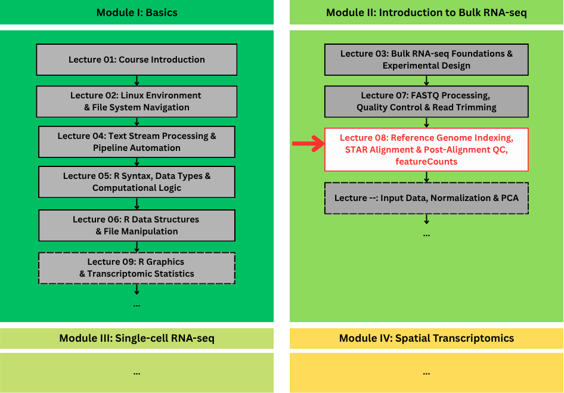

**Note**

Last week: **clean reads**. Today: **an address for every read**. Space Ranger runs STAR for Visium — so this is not a detour.

### 📦 The Data You Will Align

| Field | Value |
| --- | --- |
| Sample | `SRR8836894` — GSM3702795, PC9 control, GSE129221 |
| Layout | paired-end, 2 × 150 bp |
| Reads | 5,000 pairs |
| Reference | GRCh38 |
| Annotation | Ensembl 115 — 6,661 genes, 44,417 transcripts |
| Tools | STAR 2.7.11b · samtools 1.19.2 · featureCounts 2.1.1 |

**Note**

We run FastQC, trim with fastp, and check the result before alignment. Everything today uses **this one sample** — the alignment numbers on the slides are the numbers you will see in your notebook.

### ⏱️ No Notes, No Peeking

**Three questions. Sixty seconds each. Write your answer before I reveal it.**

Reading the answer twice teaches you nothing. Getting it wrong once and correcting it does.

### ⚡ Q1 — What Is Line 4?

```
@SRR8836894.1 1/1
GTCGGAGCACATCTTGCTGGCCCAGGTGTTCAGCAAGATGGAGCAGGTGTCTGGCGTG
+
+AFAI<FFF77<AF-AAF7FAAJJJ7JFAJ-FFF-FF--7---F<<F<AJJFFAFJJAJ-
```

**Line 4 is a quality string.** In it, the character **`I`** appears.

1. What does `I` mean?
2. What is the probability that base is wrong?

**ASCII table (excerpt)** — use it to decode `I`:

| ASCII | 70 | 71 | 72 | 73 | 74 |
| --- | --- | --- | --- | --- | --- |
| Char | `F` | `G` | `H` | **`I`** | `J` |

Phred+33: **Phred = ASCII − 33**.

### ✅ A1 — Quality, Position by Position

1. **What does `I` mean?** From the table, `I` is ASCII 73. Phred+33: **73 − 33 = Q40**.
2. **What is the probability that base is wrong?** 10<sup>−4</sup> — **one wrong base in 10,000**.

$$P(\text{error}) = 10^{-Q/10} = 10^{-4}$$

- Q30 = 1 in 1,000. Q20 = 1 in 100.
- The quality string is **positionally locked** to the sequence: base 57 and quality 57 describe the same nucleotide.

**Note**

A trimmer edits **line 2 and line 4 together**. Editing only one corrupts the record.

### ⚡ Q2 — Do You Trim?

[figure not shown]

FastQC project, Babraham Institute (Andrew Andrews)

**Does this require trimming? If yes, exactly what — and what do you leave alone?**

### ✅ A2 — Trim What the Plot Shows

**Trim adapters and the low-quality tail. Do not trim the whole read.**

**Important**

Trimming is not a ritual. **The plot is the evidence.** A clean library does not need aggressive trimming — and over-trimming creates “too short” reads that never align.

### ⚡ Q3 — Can STAR Run?

After trimming:

- `R1` has **4,998,000** records.
- `R2` has **5,000,000** records.

**Can you align these two files together?**

### ✅ A3 — Mates Must Stay in Lockstep

**No.** STAR reads mate 1 and mate 2 together, record by record. Unequal counts mean the pairing is broken.

First check:

```bash
wc -l R1.fastq R2.fastq    # both must be equal, and divisible by 4
```

Usual cause: the trimmer ran in single-end mode, or one mate was filtered out.

**Note**

Before alignment, prove the two files still describe the **same fragments**. This is a 5-second check that saves an hour.

## 🔁 1. Review: Clean Reads, Clean Decisions

**1. Review: Clean Reads, Clean Decisions**

2. The Alignment Problem

3. STAR 101

4. Reading a BAM

5. QC: Trust, but Verify

6. From BAM to Counts

1. Review: Clean Reads, Clean Decisions

### 🖥️ Colab Session — QC and Trim

- Upload `lecture-08-data.tar.gz`; unpack it into `data/`.
- Install the tools; run the mate-count and FASTQ pre-flight checks.
- Run **FastQC → fastp → FastQC → MultiQC**.

**Important**

Trim adapters and the 3′ tail — not the whole read.

**Come back when:** trimmed mates have equal line counts and the MultiQC report is open.

## 🧩 2. The Alignment Problem

1. Review: Clean Reads, Clean Decisions

**2. The Alignment Problem**

3. STAR 101

4. Reading a BAM

5. QC: Trust, but Verify

6. From BAM to Counts

2. The Alignment Problem

### We have our reads ready… Now what?

A read is a 150-letter fragment. The genome is 3 billion letters.

- **RefSeq (3 Gbp):** `ACGTAGCTTAGTTGCACGTA`
- **A read (150 bp):** `ACGTA`

**Where does this read belong?**

2. The Alignment Problem

### What “Align” Means

**Alignment = the position and strand where that fragment best matches the reference.**

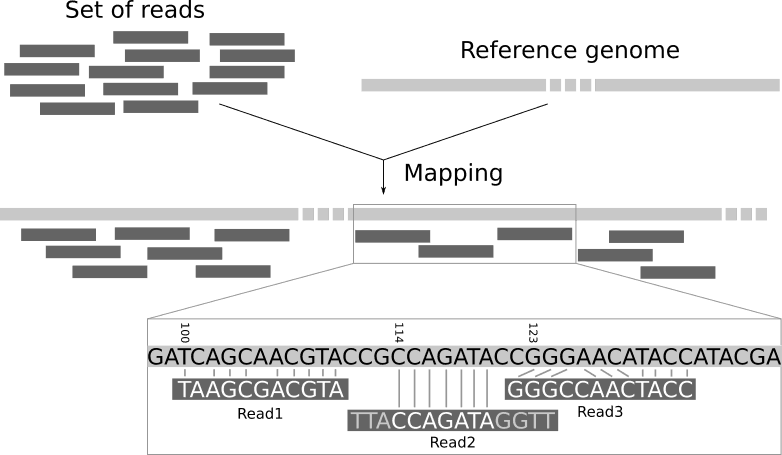

Galaxy Training Network, “Mapping” tutorial (J. Wolff, B. Batut, H. Koch), CC BY 4.0

**Note**

“Where does it map?” is not one question. It is **where, how well, and how sure**.

2. The Alignment Problem

### Why Exact Matching Fails? — Errors & Variants

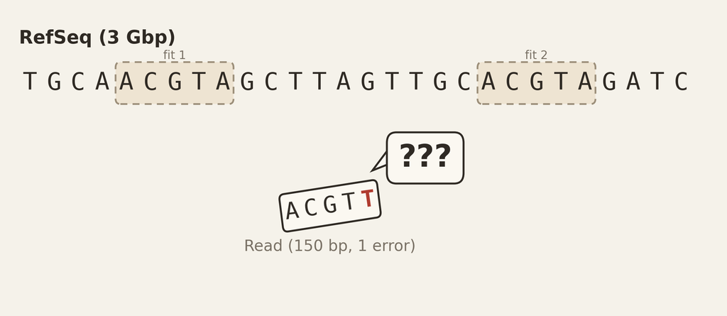

- **Sequencing errors:** ~0.1–1% of bases are wrong.
- **Variants:** a SNP or indel can still be the correct read.

**Important**

One mismatch breaks an exact match — even when the read is biologically correct.

2. The Alignment Problem

### Why Exact Matching Fails? — Repeats

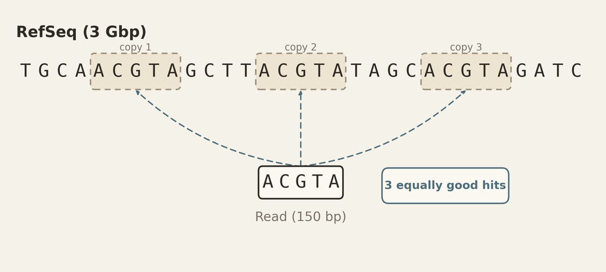

Millions of bases occur in many places. One read can have dozens of equally good homes.

**Note**

Exact matching returns many hits; the aligner must choose.

2. The Alignment Problem

### Why Exact Matching Fails? — Strandedness

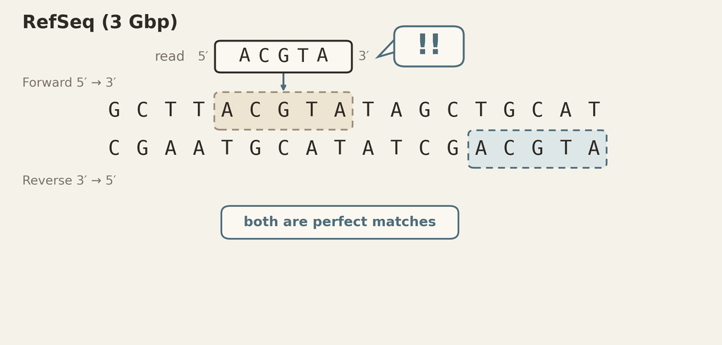

Every read has a reverse complement. The search must consider both orientations.

**Note**

A perfect match on the reverse strand is still a perfect match.

2. The Alignment Problem

### RNASeq data is astronomically HUGE!

**150 bp** against **3 Gbp**.

**Important**

Naive search: 3 Gbp × 50 M reads. **Impossible.** The index makes it possible.

2. The Alignment Problem

### The RNA-seq Twist: Splicing

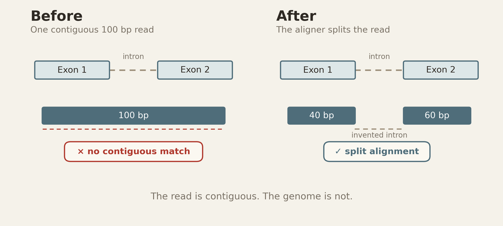

The read is contiguous. The genome is not.

An RNA-seq read can span an exon–exon junction. The aligner must **split the read** and invent an intron — not reject it as a bad match.

2. The Alignment Problem

### Two Ways to Align

|  | Genome aligner | Pseudo-aligner |
| --- | --- | --- |
| Examples | STAR, HISAT2 | salmon, kallisto |
| Output | **BAM** with coordinates | counts, no BAM |
| Splicing | explicit junctions | k-mer compatibility |
| Use here | QC, IGV, counting, Space Ranger | fast expression estimates |

**Note**

We need a **BAM**: it is the object we QC, the object we count, and the object Space Ranger produces. That is why we use STAR.

2. The Alignment Problem

### Key Notes — The Alignment Problem

- **A read is contiguous. The genome is not.** A 100 bp read can be 40 bp exon 1 + 60 bp exon 2.
- **Exact matching fails** on sequencing errors, repeats, strand, and splicing.
- **Split alignment:** `40M + intron + 60M`. The aligner searches for the gap — it does not reject the read.
- **We need a BAM**, so we choose **STAR**.

2. The Alignment Problem

### We know the problem. Now the machine.

The aligner must find a short, imperfect, possibly split match in 3 billion letters.

**Note**

Next: how STAR solves it — the suffix index, the maximal mappable prefix, and the stitch across introns.

## ⚙️ 3. STAR 101

1. Review: Clean Reads, Clean Decisions

2. The Alignment Problem

**3. STAR 101**

4. Reading a BAM

5. QC: Trust, but Verify

6. From BAM to Counts

3. STAR 101

### STAR — Spliced Transcripts Alignment to a Reference

STAR indexes every suffix of the genome, finds the longest exact prefix of each read, extends it, and stitches the pieces across introns.

**Note**

Dobin et al., *Bioinformatics* 2013. “Ultrafast” is not magic — it is an uncompressed index held in RAM.

3. STAR 101

### What STAR Does

**Four moves — for every read:**

1. **Index** — build the search structure once.
2. **Seed** — find the maximal mappable prefix (MMP).
3. **Extend** — add mismatches and gaps, scoring each extension.
4. **Stitch** — re-seed downstream when an exon boundary interrupts.

3. STAR 101

### What STAR Needs

| Input | What it is | Why STAR needs it |
| --- | --- | --- |
| FASTA | the genome sequence | the text being searched |
| GTF | exons, transcripts, genes | known splice junctions + gene models |
| **Index** | a precomputed search structure | the difference between hours and seconds |

Next: how STAR builds and uses the index.

3. STAR 101

### 🖥️ Colab Session — Start the Index

Start the index now

- Run the `genomeGenerate` cell **in the background**.
- Then `tail -f data/star_index/Log.out` once, to prove it is alive.
- **Do not wait.** It takes ~25 min on 2 vCPUs; we will spend exactly that long on the next slides.

```bash
STAR --runMode genomeGenerate \
     --genomeDir data/star_index \
     --genomeFastaFiles data/ref/Homo_sapiens.GRCh38.dna.primary_assembly.sub.fa \
     --sjdbGTFfile data/gtf/Homo_sapiens.GRCh38.sub.gtf \
     --sjdbOverhang 149 --genomeSAindexNbases 12 \
     --genomeSAsparseD 1 --runThreadN 2
# full nohup ... & command is in the notebook
```

3. STAR 101

### Index — Every Position, Sorted

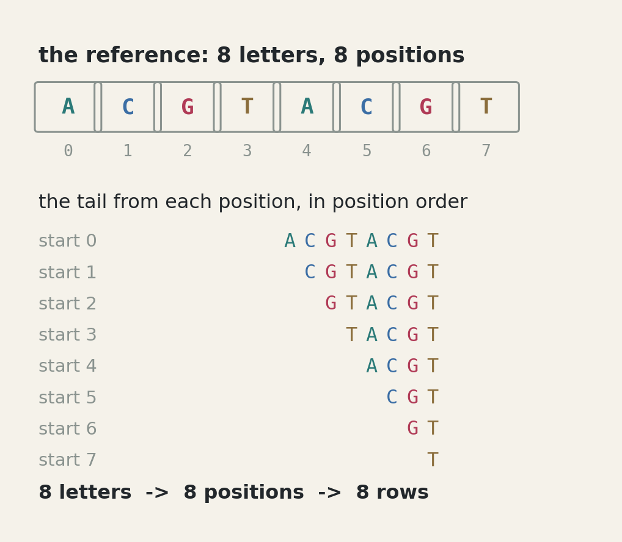

- **One row per position**: the letters from that position to the end.

Ours: 181 Mb → **180 million rows**, built once by `genomeGenerate`.

3. STAR 101

### Index — Sorted by Letters

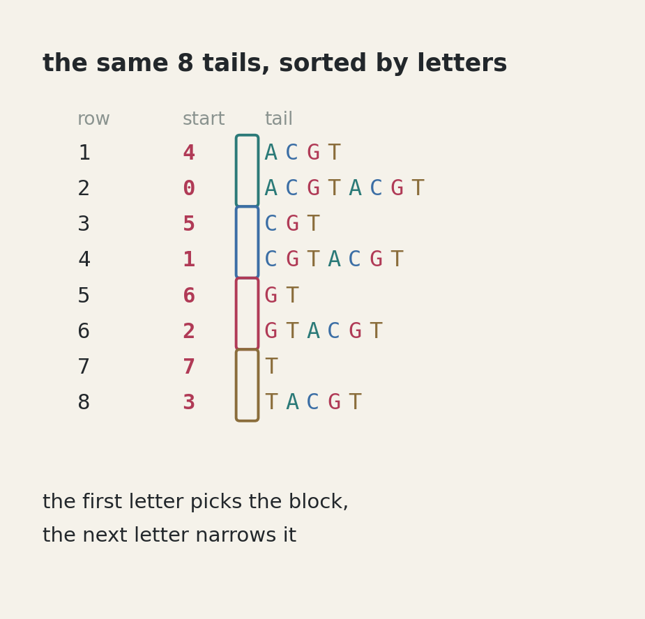

- **Sorted by letters**, the **start** column jumps around. That list is the index.
- The first letter picks the block, the next letter narrows it.

3. STAR 101

### Index — Lookup, Not Scan

Read `GTACGT` against the sorted list: one pass, narrowed at every letter.

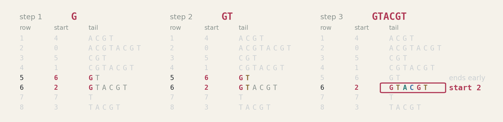

3. STAR 101

### Index — The Cost: RAM

The list is held in RAM, whole, for the entire run.

| reference | index on disk |
| --- | --- |
| 181 Mb (chr17/21/22) | **1.7 GB** |
| whole genome (3.1 Gb) | ~28 GB |

- The letters are cheap: **189 MB**.
- The **positions** are the heavy part: **1.4 GB**.

`--genomeSAsparseD` trades memory for lookup speed:

- `1` — store every position: measured **1.4 GB** (our run)
- `2` — store every second: measured **638 MB**, slower lookup

3. STAR 101

### Seed — The Longest Exact Match

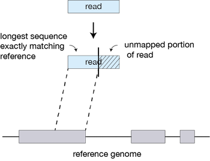

HBC Intro-to-RNA-seq, CC BY 4.0 — adapted from STAR Fig. 1

STAR takes the read and finds the longest sequence that matches the reference **exactly** — the **maximal mappable prefix (MMP)**, called **seed1**.

Everything past seed1 is left unmapped, for now.

3. STAR 101

### Seed — Searching Only the Unmapped Part

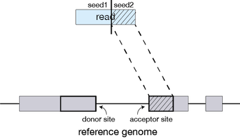

HBC Intro-to-RNA-seq, CC BY 4.0 — adapted from STAR Fig. 1

STAR then searches **only the unmapped part** of the read and finds its MMP: **seed2**.

seed2 lands far downstream, between a **donor** and an **acceptor** site — the two ends of an intron. The gap between seed1 and seed2 is the intron this read spliced over.

Searching one unmapped piece at a time is what makes STAR fast.

3. STAR 101

### Seed — Unique, Not Long

A seed does not have to be long to be useful. It only has to be **unique enough** to anchor the search.

A seed that appears everywhere anchors nothing: STAR only uses seeds that map to fewer than **10,000** places in the genome (`--seedMultimapNmax 10000`, STAR’s default, which we left alone).

3. STAR 101

### Extend — When Nothing Matches Exactly

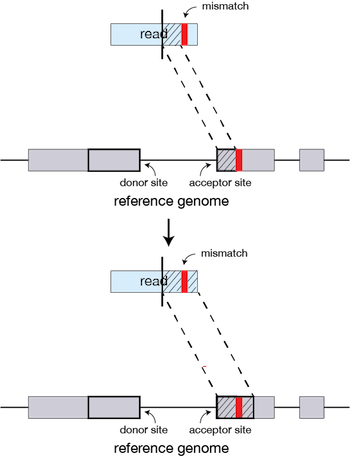

HBC Intro-to-RNA-seq, CC BY 4.0 — adapted from STAR Fig. 1

If the rest of the read has no exact match — a mismatch, an indel, a low-quality base — the previous seeds are **extended**, base by base, scoring every base added.

The red bar is a mismatch accepted during extension.

3. STAR 101

### Extend — The Soft Clip

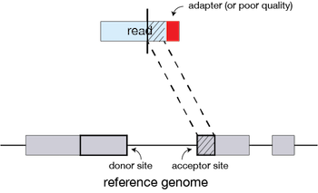

HBC Intro-to-RNA-seq, CC BY 4.0 — adapted from STAR Fig. 1

When extension does not give a good alignment, the end of the read is **soft clipped**: adapter, poor quality, or contaminating sequence.

The clipped bases are not thrown away: they stay in the record, marked `S` in the CIGAR, outside the aligned blocks.

3. STAR 101

### Stitch — Clustering and Scoring

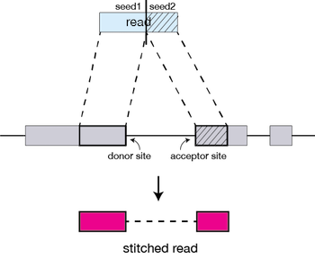

HBC Intro-to-RNA-seq, CC BY 4.0 — adapted from STAR Fig. 1

Seeds are clustered around **anchor seeds** — seeds that map to one place only — then stitched into one alignment, scored by mismatches, indels, and gaps.

The dashed line in the stitched read is the intron.

**Important**

Stitching is what makes STAR **splice-aware**.

A DNA aligner would stop at the exon boundary; STAR starts a second search.

3. STAR 101

### Stitch — Crossing an Exon Boundary

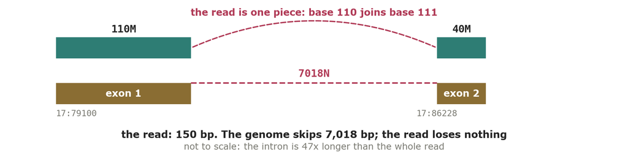

A real spliced record: 110M, a 7,018 bp intron, 40M

| piece | meaning |
| --- | --- |
| `110M` | 110 bp aligned to exon 1 |
| `7018N` | 7,018 bp skipped — an intron |
| `40M` | 40 bp aligned to exon 2 |

- the read never loses bases; the **genome** skips them
- `N` is RNA-seq’s signature

3. STAR 101

### Stitch — Annotated vs Novel Junctions

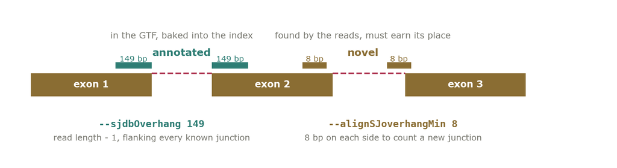

An annotated junction, flanked by 149 bp; a novel junction needing 8 bp

|  | annotated | novel |
| --- | --- | --- |
| source | GTF, baked into the index | found by the reads |
| cost | cheap, already known | must earn its place |
| control | `--sjdbGTFfile` | `--alignSJoverhangMin 8` |
| trust | high | lower, needs support |

Known junctions are the difference between a fast alignment and a search through every possible intron. `--sjdbOverhang` = read length − 1 = 149.

3. STAR 101

### The Flags, Mapped to the Algorithm

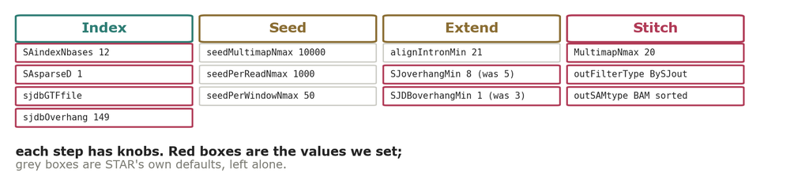

3. STAR 101

### The Flags We Set

| flag | value | what it controls |
| --- | --- | --- |
| `--genomeSAindexNbases` | 12 | lookup prefix; default 14 segfaults |
| `--genomeSAsparseD` | 1 | dense suffix array: more RAM, faster |
| `--sjdbGTFfile` | GTF | known junctions in the index |
| `--sjdbOverhang` | 149 | exon sequence flanking each junction |
| `--outFilterMultimapNmax` | 20 | maximum loci reported per read |
| `--outFilterType` | `BySJout` | junction-consistency filter |
| `--outSAMtype` | `BAM SortedByCoordinate` | sorted output, ready to index |
| `--alignSJoverhangMin` | 8 | minimum overhang at a novel junction (default 5) |
| `--alignSJDBoverhangMin` | 1 | minimum overhang at an annotated junction (default 3) |

`BySJout` is a junction-consistency filter, **not** a uniqueness filter. A read can be unique and still be filtered if its junction is implausible.

3. STAR 101

### 🎯 Flags Are Two Decisions

The index decides what the aligner can find. The run decides what the file reports.

- **At index build** — prefix 12, sparse 1, junctions from the GTF, 149 bp of flanking exon: four choices about what is visible at all.
- **At the run** — 20 loci per read, `BySJout`, overhang minimums 8 and 1, sorted BAM: four choices about what survives into the file.

3. STAR 101

### 🖥️ Colab Session — Align the Reads

Build check → alignment

- `tail data/star_index/Log.out` and `ls -lh data/star_index` — confirm the build finished.
- Run the alignment cell.
- Watch `sample.Log.progress.out` while it runs (~83 s).
- Open `sample.Log.final.out` and leave it on screen.

**Come back when the final log is generated.** We will read it together.

## 🧾 4. Reading a BAM

1. Review: Clean Reads, Clean Decisions

2. The Alignment Problem

3. STAR 101

**4. Reading a BAM**

5. QC: Trust, but Verify

6. From BAM to Counts

4. Reading a BAM

### SAM, BAM, CRAM

| Format | What it is | When you meet it |
| --- | --- | --- |
| **SAM** | plain text, one line per alignment | debugging, `samtools view` |
| **BAM** | binary, compressed, indexable | the working format |
| **CRAM** | reference-compressed | long-term archives |

**Note**

BAM is the **interchange format**: IGV reads it, featureCounts reads it, GATK reads it, Space Ranger writes it. Learn one, and the rest of the course can read the file.

4. Reading a BAM

### The Header Is the Provenance

```
@HD  VN:1.6  SO:coordinate
@SQ  SN:17  LN:83257441
@SQ  SN:21  LN:46709983
@SQ  SN:22  LN:50818468
@PG  ID:STAR  PN:STAR  VN:2.7.11b
     CL:STAR --runMode alignReads --genomeDir data/star_index ...
```

- `@HD` — file format and sort order.
- `@SQ` — the reference dictionary: names and lengths.
- `@PG` — the **exact command** that made the file.

**Important**

The BAM remembers how it was made. That is reproducibility you do not have to reconstruct from memory.

4. Reading a BAM

### QNAME and FLAG

| QNAME | FLAG | RNAME | POS | MAPQ | CIGAR | RNEXT | PNEXT | TLEN | SEQ | QUAL | tags |
| --- | --- | --- | --- | --- | --- | --- | --- | --- | --- | --- | --- |
| SRR8836894.3781 | 99 | 17 | 79100 | 255 | 110M7018N40M | = | 79158 | 7225 | GGCACAATGGCT… | AAFFFJJFAAJ<… | NH:i:1 AS:i:282 … |

4. Reading a BAM

### FLAG, Decoded

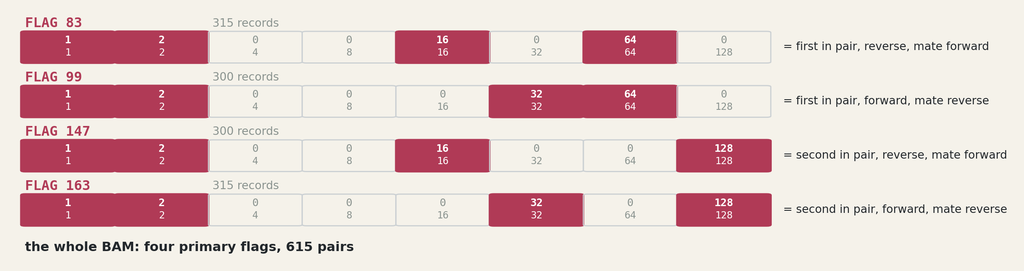

Four flags from our BAM, decomposed into the bits that sum to them

- the bits **sum** to the number: 99 = 1 + 2 + 32 + 64
- 4, 8: *unmapped, no mate* — special cases; 512, 1024: secondary, duplicate
- 2, 4, 8, 512, 1024 are mutually exclusive; 1, 16, 32, 64, 128 combine freely

4. Reading a BAM

### RNAME and POS

| QNAME | FLAG | RNAME | POS | MAPQ | CIGAR | RNEXT | PNEXT | TLEN | SEQ | QUAL | tags |
| --- | --- | --- | --- | --- | --- | --- | --- | --- | --- | --- | --- |
| SRR8836894.3781 | 99 | 17 | 79100 | 255 | 110M7018N40M | = | 79158 | 7225 | GGCACAATGGCT… | AAFFFJJFAAJ<… | NH:i:1 AS:i:282 … |

- `RNAME` is the contig as STAR wrote it: `17`, not `chr17`.
- `POS` is 1-based, the leftmost **aligned** base: `79100`.
- With a spliced CIGAR, `POS` is the left end of the *first* block. This record ends at `86267`; `POS` + read length is not the end.

4. Reading a BAM

### MAPQ

| QNAME | FLAG | RNAME | POS | MAPQ | CIGAR | RNEXT | PNEXT | TLEN | SEQ | QUAL | tags |
| --- | --- | --- | --- | --- | --- | --- | --- | --- | --- | --- | --- |
| SRR8836894.3781 | 99 | 17 | 79100 | 255 | 110M7018N40M | = | 79158 | 7225 | GGCACAATGGCT… | AAFFFJJFAAJ<… | NH:i:1 AS:i:282 … |

- `MAPQ` answers: *how much do you trust this placement?*
- 255 means one place in the genome. 1,106 of our 1,230 primary records are 255.
- 48 records are `MAPQ 3`, 76 are `MAPQ 1` — they fit in more than one place, and STAR is telling you.
- A low `MAPQ` is not a bad read. It is an honest read.

`MAPQ` gets the next slide, with the distribution.

4. Reading a BAM

### MAPQ Distribution

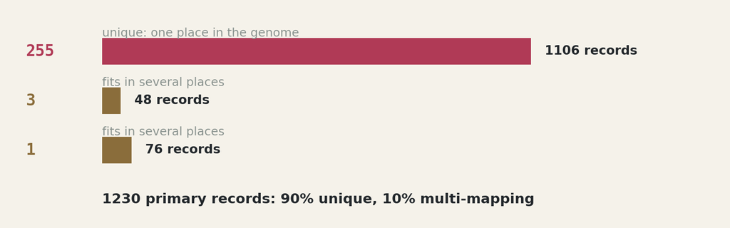

MAPQ distribution in our BAM: 1,106 primary records at 255, 124 below

| `MAPQ` | measured in our BAM |
| --- | --- |
| **255** | **one place** — 1,106 primary records |
| 124 records below | shown in the figure |

- 124 primary records are lower than 255: 48 at `MAPQ 3`, 76 at `MAPQ 1`
- `Log.final.out` counts them: 553 uniquely mapped (11.06%), 62 mapped to multiple loci (1.24%)

Low `MAPQ` is honesty, not failure: the read fits in more than one place, and STAR is telling you so. The `NH` tag, at the end of the record, is where STAR writes that number down.

4. Reading a BAM

### CIGAR

| QNAME | FLAG | RNAME | POS | MAPQ | CIGAR | RNEXT | PNEXT | TLEN | SEQ | QUAL | tags |
| --- | --- | --- | --- | --- | --- | --- | --- | --- | --- | --- | --- |
| SRR8836894.3781 | 99 | 17 | 79100 | 255 | 110M7018N40M | = | 79158 | 7225 | GGCACAATGGCT… | AAFFFJJFAAJ<… | NH:i:1 AS:i:282 … |

- `110M7018N40M`: 110 aligned, 7,018 skipped, 40 aligned.
- `N` is the intron. The genome jumps; the read loses nothing.
- Reference span `79100–86267`, measured from the record. `CIGAR` gets its own slide, with the figure.

4. Reading a BAM

### CIGAR, Decoded

[figure not shown]

A spliced record: 110M, then a 7,018 bp gap, then 40M

- `M` aligned · `I` insert in read · `D` delete from reference · `N` intron · `S` soft-clip
- `5M10I` = five aligned, ten inserted: **an insertion**
- `S` bases are in the `SEQ` but not counted in `POS`

**Important**

`N` is not a deletion. The read did not lose 7,018 bases — the **genome** skips them. That is a spliced alignment.

**You will see this arc in IGV, Section 5.**

4. Reading a BAM

### RNEXT and PNEXT

| QNAME | FLAG | RNAME | POS | MAPQ | CIGAR | RNEXT | PNEXT | TLEN | SEQ | QUAL | tags |
| --- | --- | --- | --- | --- | --- | --- | --- | --- | --- | --- | --- |
| SRR8836894.3781 | 99 | 17 | 79100 | 255 | 110M7018N40M | = | 79158 | 7225 | GGCACAATGGCT… | AAFFFJJFAAJ<… | NH:i:1 AS:i:282 … |

- `RNEXT` is the mate’s contig. `=` means *the same chromosome as this record*.
- `PNEXT` is the mate’s `POS`: `79158`, 58 bases to the right.
- The mate is flag `147`, `52M7018N97M1S`, ending `86324`. Same read name, same intron, opposite end of the fragment.

4. Reading a BAM

### TLEN

| QNAME | FLAG | RNAME | POS | MAPQ | CIGAR | RNEXT | PNEXT | TLEN | SEQ | QUAL | tags |
| --- | --- | --- | --- | --- | --- | --- | --- | --- | --- | --- | --- |
| SRR8836894.3781 | 99 | 17 | 79100 | 255 | 110M7018N40M | = | 79158 | 7225 | GGCACAATGGCT… | AAFFFJJFAAJ<… | NH:i:1 AS:i:282 … |

- `TLEN 7225` is the **fragment**: leftmost start `79100` to rightmost end `86324`, counted across the intron.
- The sign is read–mate order: `+7225` on flag 99, `-7225` on flag 147.
- Not the gap between the two `POS` — `79158 - 79100` is 58. `TLEN` is what library prep calls fragment size.

4. Reading a BAM

### SEQ and QUAL

| QNAME | FLAG | RNAME | POS | MAPQ | CIGAR | RNEXT | PNEXT | TLEN | SEQ | QUAL | tags |
| --- | --- | --- | --- | --- | --- | --- | --- | --- | --- | --- | --- |
| SRR8836894.3781 | 99 | 17 | 79100 | 255 | 110M7018N40M | = | 79158 | 7225 | GGCACAATGGCT… | AAFFFJJFAAJ<… | NH:i:1 AS:i:282 … |

- `SEQ` is the read, 150 bases. It includes bases the aligner did not match: the mate’s `52M7018N97M1S` aligns 149 and **soft-clips 1**.
- `QUAL` is one character per base, same length as `SEQ`: `# ) - 7 < A F J` in our BAM.
- Phred: character − 33, so `#` is Q2, `J` is Q41.

4. Reading a BAM

### The STAR Tags

| QNAME | FLAG | RNAME | POS | MAPQ | CIGAR | RNEXT | PNEXT | TLEN | SEQ | QUAL | tags |
| --- | --- | --- | --- | --- | --- | --- | --- | --- | --- | --- | --- |
| SRR8836894.3781 | 99 | 17 | 79100 | 255 | 110M7018N40M | = | 79158 | 7225 | GGCACAATGGCT… | AAFFFJJFAAJ<… | NH:i:1 AS:i:282 … |

Tags come after the 11 mandatory fields, on the same line. `samtools view` prints them.

4. Reading a BAM

### Reading the Columns

| what you ask | column | example |
| --- | --- | --- |
| which read? | `QNAME` | `SRR8836894.3781` |
| pair? mate? mapped? | `FLAG` | `99` |
| **where?** | `RNAME`, `POS` | `17`, `79100` |
| **how sure?** | `MAPQ` | `255` |
| **what shape?** | `CIGAR` | `110M7018N40M` |
| bases, quality | `SEQ`, `QUAL` | 150 letters, Phred |
| mate position | `RNEXT`, `PNEXT` | `=`, `79158` |
| fragment length | `TLEN` | `7225` |

4. Reading a BAM

### Sort, Index, `.bai`

1. **Coordinate sort** — records ordered by chromosome and position.
2. **Index** — a lookup table from region to file offset.
3. **Random access** — IGV and `samtools view file region` become instant.

```bash
samtools index sample.Aligned.sortedByCoord.out.bam
```

**Important**

`samtools idxstats` and region queries need the `.bai`. Without it, they fail with “random alignment retrieval only works for indexed BAMs.” Build the index; do not work around it.

4. Reading a BAM

### What STAR Writes

| File | What it is | Use today |
| --- | --- | --- |
| `*.Aligned.sortedByCoord.out.bam` | sorted alignments | yes |
| `*.Log.final.out` | summary metrics | **yes** |
| `*.Log.out` | every parameter and step | debugging |
| `*.Log.progress.out` | live progress | while it runs |
| `*.SJ.out.tab` | splice junctions | **yes** |
| `_STARtmp/` | temporary sort files | delete after success |

**Note**

Three files carry the lecture: the **BAM** (evidence), `Log.final.out` (the aligner’s opinion), and `SJ.out.tab` (where the introns are).

4. Reading a BAM

### 🧰 Also in a Real Pipeline

| Flag | What it buys you |
| --- | --- |
| `--readFilesCommand zcat` | align `.fastq.gz` directly — no manual decompression |
| `--outReadsUnmapped Fastx` | write the unmapped reads, so you can BLAST them and find contamination |
| `--quantMode GeneCounts` | STAR counts per gene itself — an alternative to featureCounts |
| `--outSAMattrRGline` | read groups, needed downstream by GATK (not by counting) |

**Note**

None of these change the concepts. They are the difference between a notebook and a production pipeline.

4. Reading a BAM

### 🖥️ Colab Session — Dissect Your BAM

Read the file you just made

- `samtools view -H` — find `@PG` and the exact command.
- `samtools view | head -1` — decode FLAG, CIGAR, MAPQ.
- `samtools view | awk '$6 ~ /N/' | head -3` — find a spliced read.
- `samtools view -c` vs `samtools view -c -F 256` — how many records are primary?

**Come back when you can decode one record out loud.**

4. Reading a BAM

### ✍️ Decode This Record

SRR8836894.3116 99 17 1875710 255 84M1418N66M = 1878996 3589 NH:i:1

1. Is this read paired?
2. Is the pair proper?
3. Which mate is it?
4. How many loci does it have?
5. Is it spliced — and how do you know?

4. Reading a BAM

### ✅ Decode This Record — Answers

1. **Paired** — bit 1 is set.
2. **Proper pair** — bit 2 is set.
3. **First in pair** — bit 64; mate is reverse (bit 32).
4. **One locus** — MAPQ 255; `NH:i:1`.
5. **Spliced** — `1418N` in the CIGAR: 84 bp exon, 1,418 bp intron, 66 bp exon, and 84 + 66 = 150 bp of read.

**Tip**

`TLEN 3589` spans from this read’s start (1,875,710) to its mate’s end (1,879,298). It is the insert size — which the next section will use as a QC check.

4. Reading a BAM

### 🎯 One Line, Five Claims

The record states where, how, and how well. Every claim can be re-derived from the columns.

- `17 1875710` is the **address**: chromosome, then 1-based start.
- `99` is the **shape**: paired, proper, first of the pair, mate on the reverse.
- `84M1418N66M` is the **geometry**: exon, intron, exon.
- `255` with `NH:i:1` is the **confidence**: one locus, STAR’s top score.
- `3589` is the **pair**: this read’s start to its mate’s end.

**Important**

This record is `SRR8836894.3116` from our own STAR run, not an invented example. Its mate reads `147 17 1878996 255 66M153N84M`, the same pair seen from the other side.

## 📊 5. QC: Trust, but Verify

1. Review: Clean Reads, Clean Decisions

2. The Alignment Problem

3. STAR 101

4. Reading a BAM

**5. QC: Trust, but Verify**

6. From BAM to Counts

5. QC: Trust, but Verify

### Two Layers of QC

#### The aligner’s opinion

`Log.final.out` — how many reads mapped, how well, how many splices, how many were discarded.

#### The evidence

The BAM itself — `flagstat`, `idxstats`, MAPQ, insert size, coverage. What actually landed.

**Five questions:**

1. How many reads made it?
2. Where did they go?
3. How well did they align?
4. Are the pairs sane?
5. Is the coverage believable?

5. QC: Trust, but Verify

### `Log.final.out`, Annotated

| Field | Ours | What it tells you |
| --- | --- | --- |
| Number of input reads | 5,000 | fragments in |
| Uniquely mapped reads % | **11.06%** | the headline number |
| % of reads mapped to multiple loci | 1.24% | repeats / ambiguity |
| % of reads unmapped: too short | small | over-trimming signal |
| Number of splices: Total | **443** | how much splicing was found |
| Mismatch rate per base | see log | wrong reference / contamination signal |

**Important**

Read it top to bottom. **Every line is a failure mode** with a number attached.

5. QC: Trust, but Verify

### The Denominator Trap

```
5,000 input fragments
  × (11.06% unique + 1.24% multi) = 615 fragments
  × 2 mates                        = 1,230 primary records
  + 242 secondary                  = 1,472 records
```

`samtools flagstat` says: **1,472 total · 1,230 primary · 242 secondary**.

**Important**

STAR counts **fragments** (pairs). `flagstat` counts **records** (mates). 11% of 5,000 is not 553 records — it is 553 **fragments**, which is 1,106 **mates**, plus multi-mappers.

5. QC: Trust, but Verify

### `flagstat`, Annotated

| Line | Ours | Meaning |
| --- | --- | --- |
| in total | 1,472 | every record in the BAM |
| primary | 1,230 | one per fragment |
| secondary | 242 | extra loci for multi-mappers |
| duplicates | 0 | not marked; meaningless at this depth |
| properly paired | 1,230 (100%) | over **primary**, not input |
| read1 / read2 | 615 / 615 | the pair is balanced |

**Note**

5. QC: Trust, but Verify

### `idxstats` and the 3-Chromosome Reality

| Contig | Length | Mapped |
| --- | --- | --- |
| `17` | 83,257,441 | **830** |
| `21` | 46,709,983 | **378** |
| `22` | 50,818,468 | **264** |
| `*` | — | 0 |

830 + 378 + 264 = 1,472

**Important**

The arithmetic closes against `flagstat`. That is the single best end-to-end check in the notebook: if these do not match, one of your assumptions is wrong.

5. QC: Trust, but Verify

### MAPQ: How Sure Are We?

```bash
samtools view sample.bam | cut -f5 | sort -n | uniq -c
```

Expect a **spike at 255** (unique) and a small tail at 0–3 (multi-mapping).

- MAPQ 255 is STAR’s “unique” label — it is not a probability.
- A large 0–3 tail means repeats or rRNA.
- MAPQ 0 can also mean “unmapped” — check FLAG bit 4.

**Note**

MAPQ answers “how many places could this read come from?” — not “how correct is this base?”

5. QC: Trust, but Verify

### Insert Size, Coverage, Bias

#### Insert size

`samtools stats | grep “insert size”`. A sharp peak is healthy. A bizarre spread means a library or pairing problem.

#### 5′ / 3′ bias

Coverage should be even across the gene. A slope means degraded RNA or a library-prep bias.

#### rRNA / chrM

A few genes dominating the reads usually means rRNA contamination. chrM is absent from our reference, so we cannot see it here.

#### Strand bias

Reads should not pile onto one strand unless the protocol is stranded. A strong skew means the wrong library chemistry.

At 5,000 pairs these are concepts, not measurements. Qualimap and RNA-SeQC do them properly at real depth.

5. QC: Trust, but Verify

### Red Flags

| Symptom | Usual cause | First check |
| --- | --- | --- |
| Unique rate very low | wrong reference / contig naming / rRNA | `@SQ` names vs FASTA/GTF |
| Many “too many loci” | repeats, rRNA, short reads | `--outFilterMultimapNmax`, FastQC |
| Mismatch > 2–3% | wrong species/assembly, contamination | reference build |
| Many “too short” | over-trimming | trim settings, read length |
| 5′/3′ bias | degraded RNA / library | RIN, coverage plot |
| Duplicates > 50% | PCR over-amplification | only meaningful at real depth |

**Note**

**One number is never a diagnosis.** The red flag is a pattern across logs, not a single threshold.

5. QC: Trust, but Verify

### Is 11% Bad?

No. The denominator is the reference, not the sample.

- A whole-genome RNA-seq run expects **80–90%** unique.
- Here, only **5.85%** of the genome is indexed — and it is gene-dense.
- The honest statement for a methods section: *“11.1% of reads mapped uniquely to the three-chromosome reference; the remaining reads are outside the indexed contigs.”*

**Tools for real data:** Qualimap (5′/3′, duplication, coverage), MultiQC (aggregates logs), IGV (eyes on a locus).

5. QC: Trust, but Verify

### 👁️ Eyes on a Locus — Coverage

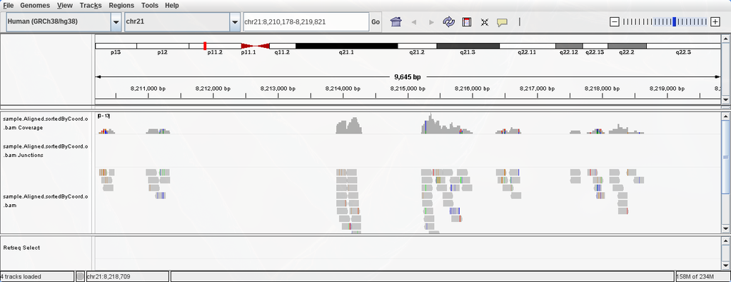

**chr21:8,210,178–8,219,821** — 9,645 bp, **74 records**.

- Coverage arrives in islands. Peak depth **13×**.
- **12 records** carry soft clips: `149M1S`, `88M62S`, `114M36S`.
- **2** annotated exons in the window. **7 of 74** reads start inside one.
- The other 67 land off features — `Unassigned_NoFeatures` seen with eyes.

A log gives the average. **The locus shows what the average is hiding.**

5. QC: Trust, but Verify

### 👁️ A Spliced Locus — IGV

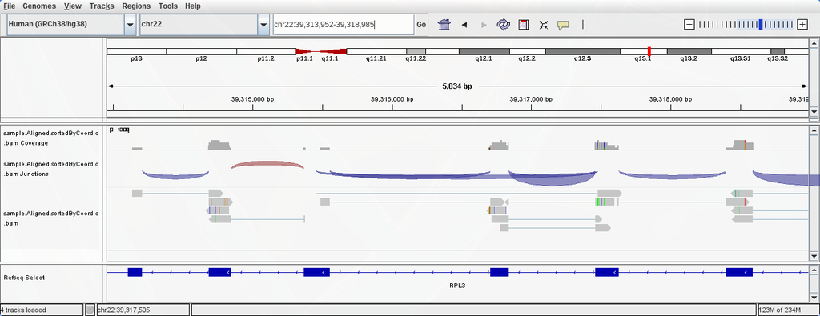

**chr22:39,313,952–39,318,985** — gene **RPL3**, **14 records**, **7 junction arcs**.

- Longest intron: **2,020 bp** at 39,315,458–39,317,478.
- That junction has **4 uniquely-mapping** reads and **1 multi-mapping** read.
- Motifs: **5 GT/AG**, **1 GC/AG**, **1 AT/AC**.
- Every arc here is annotated in the index. The arcs are the `N` in the CIGAR — you decoded one in Section 4.

**Note**

**Load** BAM + `.bai` · FASTA · GTF. **Read** the arcs, not just the pileup.

5. QC: Trust, but Verify

### 🖥️ Colab Session — QC + Counts

Verify, then count

- `samtools index` — build the `.bai`.
- `samtools flagstat`, `idxstats`, `stats | grep "insert size"`.
- MAPQ histogram.
- **Reproduce 615 → 1,230 → 1,472** in a markdown cell.
- `featureCounts` — then read the `.summary` rows, not just the matrix.

**Come back when the arithmetic closes.**

5. QC: Trust, but Verify

### ✍️ Exercise A

**2% uniquely mapped. 70% “too many loci.”**

What is going on?

1. the reads are too short to align
2. the reads match many places in the genome
3. the reference is missing contigs

5. QC: Trust, but Verify

### ✅ Exercise A — Answer

**Option 2: the reads match many places in the genome.**

Repeats or rRNA: many loci match, so STAR reports “too many loci” instead of guessing. Too-short reads are reported as “too short”, and a missing contig gives unmapped reads, not a loci warning.

5. QC: Trust, but Verify

### ✍️ Exercise B

**95% mapped. 40% mismatch rate.**

What do you suspect?

1. the library is duplicated
2. soft-clipped bases are being counted as mismatches
3. the reference does not match the reads

5. QC: Trust, but Verify

### ✅ Exercise B — Answer

**Option 3: the reference does not match the reads.**

40% mismatch means the reference is not the species, or not the assembly version, the reads came from. Duplicates do not raise the mismatch rate, and soft-clipped bases are not counted as mismatches.

5. QC: Trust, but Verify

### ✍️ Exercise C

**Properly paired: 60%. Insert sizes huge.**

What is broken?

1. the library: fragments are long, pairing is off
2. the aligner is missing introns
3. `MAPQ` is too low

5. QC: Trust, but Verify

### ✅ Exercise C — Answer

**Option 1: the library.**

Long fragments and lost proper pairs are library prep and pairing. Look at the insert size distribution before you blame the aligner: missing introns show up in `CIGAR`, not in `FLAG`.

5. QC: Trust, but Verify

### ✍️ Exercise D

**10% of all reads land on one small contig.**

Most likely?

1. that contig is the largest in the genome
2. those reads are properly paired
3. contamination, or a contig the aligner cannot resolve

5. QC: Trust, but Verify

### ✅ Exercise D — Answer

**Option 3: contamination, or a contig the aligner cannot resolve.**

A small contig carrying 10% of the reads is rRNA, adapter, or spike-in. It can also be a collapsed repeat: every copy maps to one place. Size and pairing do not explain a pile-up on a small contig.

## 🧮 6. From BAM to Counts

1. Review: Clean Reads, Clean Decisions

2. The Alignment Problem

3. STAR 101

4. Reading a BAM

5. QC: Trust, but Verify

**6. From BAM to Counts**

6. From BAM to Counts

### What featureCounts Takes

```bash
featureCounts -p --countReadPairs -T 2 \
  -t exon -g gene_id -a annotation.gtf \
  -o counts.txt sample.bam
```

- the BAM is the input, the GTF is the question
- `-t exon` is what to count, `-g gene_id` is what to report
- `-p --countReadPairs` counts the pair, not the two reads

6. From BAM to Counts

### Fragments, Not Reads

- our BAM: 1,472 records, 1,230 primary alignments
- featureCounts read it as **736 fragments**
- **448 assigned (60.9%)** — that is the only number that becomes a count in the matrix

6. From BAM to Counts

### The Overlap Decision

```
BAM ──► fragment ──► overlaps an exon? ──► gene_id
                         │
                         ├── no   → Unassigned_NoFeatures
                         ├── many → Unassigned_Ambiguity
                         └── multi → Unassigned_MultiMapping
```

**Important**

featureCounts’ own defaults, printed in its setting block: *Multimapping reads: not counted*, *Multi-overlapping reads: not counted*, *Min overlapping bases : 1*. A fragment that touches two genes is not split between them.

6. From BAM to Counts

### Where the 736 Fragments Go

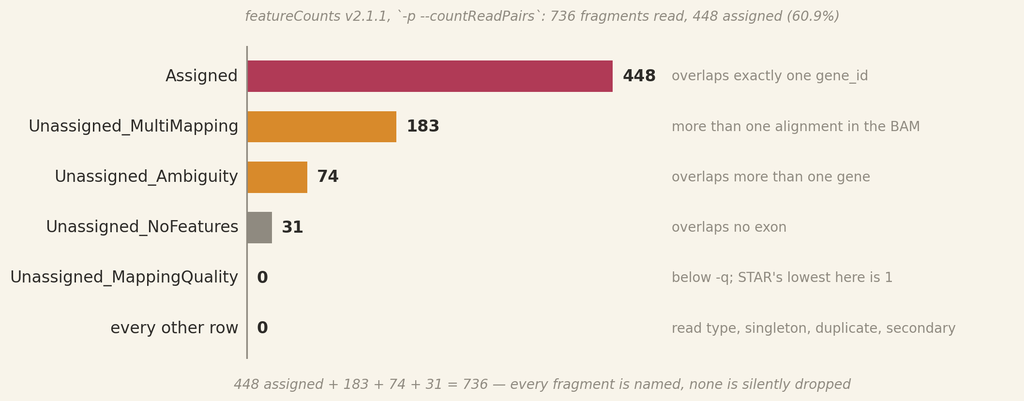

featureCounts assignment summary, measured from our run

- 448 assigned, 288 unassigned, 736 total
- every unassigned fragment is named by cause: multi-mapping, ambiguity, no features
- `Unassigned_MappingQuality` is 0: STAR’s lowest `MAPQ` here is 1, and the default `-q 0` filters nothing

6. From BAM to Counts

### Strandedness Is a Choice: `-s`

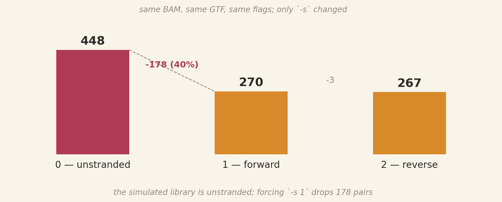

Same BAM, same GTF, only `-s` changed

- `-s 0` unstranded · `-s 1` forward · `-s 2` reverse
- the simulated library is unstranded, so `-s 0` keeps 448 pairs
- forcing `-s 1` gives 270 and `-s 2` gives 267: 40% of the data thrown away

**Important**

The wrong `-s` is the most common “my matrix looks wrong” bug. Check your library, not the tutorial you copied the command from.

6. From BAM to Counts

### From 448 Pairs to a Matrix

- rows: 6,661 genes, straight from the GTF
- 253 rows have a non-zero count; the sample column sums to 448
- `Chr` and `Start` list one entry per exon, separated by semicolons

6. From BAM to Counts

### Read the Summary, Not Just the Matrix

**Note**

The matrix is the numerator. **The summary is the diagnosis.** 183 + 74 + 31 is not noise: it says multimapping, overlapping genes, intergenic sequence, in that order. If `Assigned` is low, the problem is usually alignment or annotation — not counting.

6. From BAM to Counts

### 🎯 The One-Sentence Version

A FASTQ record knows its letters. It does not know where it came from.

- **Alignment** gives every read a genomic address: chromosome, position, strand.
- **A BAM** stores that address, plus the shape and confidence of the match.
- **QC** is the decision that the addresses are trustworthy enough to count.

**Important**

Today is not “run a tool.” Today is **read what the tool produces** and decide whether to believe it.

6. From BAM to Counts

### 📚 Sources & Licenses

- **Aligner:** Dobin A, Davis CA, Schlesinger F, et al. *STAR: ultrafast universal RNA-seq aligner.* Bioinformatics 29(1):15–21, 2013. DOI 10.1093/bioinformatics/bts635.
- **Seed / extension / stitching diagrams:** “Alignment with STAR”, *Introduction to RNA-seq on the O2 cluster*, Harvard Chan Bioinformatics Core — M. Mistry, B. Freeman, M. Piper. **CC BY 4.0.** Diagrams are adapted from the STAR paper.
- **Mapping overview:** Galaxy Training Network, *Mapping* tutorial — J. Wolff, B. Batut, H. Koch. **CC BY 4.0.**
- **Counter:** Liao Y, Smyth GK, Shi W. *featureCounts: an efficient general purpose program for assigning sequence reads to genomic features.* Bioinformatics, 2014. DOI 10.1093/bioinformatics/btt656.
- **FastQC screen:** FastQC project, Babraham Institute.
- **IGV screenshots** (`igv.png`, `igv_splice.png`): captured for this course from our own STAR BAM, on IGV (Broad Institute, MIT license), Human GRCh38/hg38 with the Ensembl subset GTF loaded.
- **Every other figure in this deck was generated for this course** — the generator scripts are in `lecture-08/scripts/`. The `bam_*.png` and `fc_*.png` figures are measured from our own STAR run and our own featureCounts run, not drawn by hand.
- **Data:** Ensembl GRCh38 subset (chr17, chr21, chr22) + simulated reads, and STAR’s own sample `Log.progress` files.

## 🚀 What’s Next?

### Input Data, Normalization & PCA — from count matrix to sample structure

- **Input data**: the count matrix from `featureCounts` — genes × samples
- **Normalization**: depth differs between samples; CPM, TPM, and DESeq2 size factors put them on one scale
- **PCA**: log-transform, project. Replicates cluster; a batch shows up as one axis
- **Real data**: QC plots, sample clustering, and the first batch effect you will have to explain

**Important**

Everything downstream inherits the BAM. A mapping you did not verify becomes a PCA you cannot interpret.

## Thank You!

> *“A FASTQ record knows its letters. It does not know where it came from. Align the reads, and the features appear — exon, intron, gene, count.”*